# Rob Cavanaugh’s CV

Rob Cavanaugh

2021-04-17

# Aside

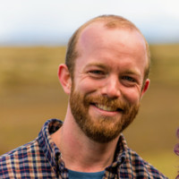

## Contact

- rob.cavanaugh@pitt.edu
- robcavanaugh.com
- [Github](https://github.com/rbcavanaugh)
- 0000-0002-2114-6565
- [Twitter](https://twitter.com/Littlejohnsband)

## Key Interests

- Aphasia treatment outcomes
- Implementation Science
- Data science & Statistics
- #R Stats & R Shiny

## Disclaimer

[Download a PDF of this CV](https://github.com/rbcavanaugh/CV/raw/master/cv.pdf/)

Last updated on 2021-04-17.

# Main

## Robert Cavanaugh

I’m a certified speech-language pathologist and Ph.D student in the Department of Communication Science and Disorders at the University of Pittsburgh. I am also hold a TL1 predoctoral fellowship in the Institute of Clinical Research Education. I have worked clinical in inpatient and outpatient rehabilitation settings, primarily with patients with neurogenic communication disorders stemming from stroke, traumatic brain injury, and degenerative diseases such as amyotrophic lateral sclerosis, multiple sclerosis and dementia. My research currently focuses on the translation and clinical implementation of treatments for aphasia. I’m also interested in advanced statistical methods to CSD research, health services research, and clinical instruction.

## Education

### PhD Student, Communication Science and Disorders

University of Pittsburgh

Pittsburgh, PA

Current - 2018

### M.S. Speech and Hearing Sciences

University of North Carolina at Chapel Hill

Chapel Hill, NC

2015 - 2013

- Thesis: Working Memory Capacity and Subjective Communication  
  Difficulties in High Level Aphasia

### B.A. Communication Science and Disorders

University of Pittsburgh

Pittsburgh, PA

2013 - 2009

- Magna cum laude

## Appointments & Positions

### Predoctoral Fellow

Institute for Clinical Research Education  
University of Pittsburgh  
TL1TR001858 (PI: Kraemer)

N/A

Current - 2019

### Graduate Student Researcher

Language Rehab and Cognition Lab  
University of Pittsburgh  
PI: William S. Evans

N/A

Current - 2018

### Research Associate, WOC

Department of Speech Pathology and Audiology  
VA Pittsburgh Healthcare System

N/A

Current - 2018

### Graduate Research Assistant

Center for Aphasia and Related Disorders  
UNC - Chapel Hill  
PI: Katarina Haley

N/A

2015 - 2013

### Undergraduate Research Assistant

Eye and Ear Institute  
University of Pittsburgh Medical Center  
PI: Patrick Sparto

N/A

2013 - 2010

## Clinical Training

### Speech-Langauge Pathologist II

Carolinas Rehabilitation, Atrium Health  
Formerly, Carolinas Healthcare System

Charlotte, NC

2018 - 2016

### Speech-Langauge Pathologist II

Carolinas Neurosciences Institute, Atrium Health

Charlotte, NC

2018 - 2016

### Speech-Langauge Pathologist - Clinical Fellow

Carolinas Rehabilitation, Atrium Health

Charlotte, NC

2016 - 2015

## Grant Support

### NIH-NIDCD NRSA individual predoctoral fellowship: *Determinants of multilevel discourse outcomes in anomia treatment for aphasia*

Role: PI; Impact Score: 25  
Sponsors: Michael Walsh Dickey & William S. Evans

N/A

pending

### The University of Pittsburgh CTSI–Clinical and Translational Science Fellowship: *Comparing Treatment Intensity between Research and Clinical Practice in Post-Stroke Aphasia*

Role: Predoctoral Fellow  
TL1TR001858 (PI: Kraemer)  
Mentors: Michael Walsh Dickey, William S. Evans, & Catherine Palmer

N/A

Current - 2019

### School of Health and Rehabilitation Sciences Research Development Fund

Role: PI; Direct Costs: $1000  
Faculty Sponsor: William S. Evans

N/A

2019

## Publications

Evans, WS, **Cavanaugh, RB,** Quique, Y, Boss, E, Starns, JJ, Hula, WD. (in press). Playing with BEARS: Balancing Effort, Accuracy, and Response Speed in a Semantic Feature Verification Anomia Treatment Game. Journal of Speech, Language, and Hearing Research.

N/A

in press

N/A

2021

**Cavanaugh, R.B.,** Haley, K.L. (2020) Subjective communication difficulties in very mild aphasia. American Journal of Speech-Language Pathology, 29(1S), 437–448. https://doi.org/10.1044/2019_AJSLP-CAC48-18-0222

N/A

2020

**Cavanaugh, R.B.,** Kravetz, C., Jarold, L., Quique, Y., Turner, R., Evans, W.S. (manuscript under review). Is there a research-practice dosage gap in aphasia rehabilitation?

N/A

under review

## Refereed Presentations

**Cavanaugh, R.B.**, Kravetz, C., Jarold, L., Quique, Y., Turner, R., Evans, W.S. (2021). Is there a research-practice dosage gap in aphasia rehabilitation? Abstract for poster presentation, Aphasia Access Leadership Summit, online.

N/A

2021

**Cavanaugh, R.B.**, Kravetz, C., Jarold, L., Quique, Y., Turner, R., Evans, W.S. (2020). Is there a research-practice dosage gap in aphasia rehabilitation? Abstract for poster presentation, 16th Annual Rehabilitation Institute Research Day. Pittsburgh, PA

N/A

2020

**Cavanaugh, R.B.,** Terhorst, L., Swiderski, A.W., Hula, W.D., Evans, W.S. (2020). A Systematic Appraisal of Individual Effect Sizes in Aphasia Single-Case Designs via Simulation. Abstract for poster presentation, 58th Academy of Aphasia, Philadelpha PA.

N/A

2020

**Cavanaugh, R.B.,** Quique, Y, Boss, E, Hula, W.D., and Evans, W.S. (2020). Practicing with BEARS: Active Ingredients in Semantic Feature Analysis. Abstract for poster presentation, 49th annual Clinical Aphasiology Conference, Whitefish, MT (Conference canceled).

N/A

2020

Evans, W.S., **Cavanaugh, R.B.,** Quique, Y., Boss,E., Dickey, M.W., Doyle , P, Starns,J.J.,and Hula, W.D., (2020). BEARS-Balancing Effort, Accuracy, and Response Speed in semantic feature verification anomia treatment. Abstract for platform presentation, 49th annual Clinical Aphasiology Conference, Whitefish, MT (Conference canceled).

N/A

2020

Quique,Y., **Cavanaugh, R.B.,** Starns, J.J., Boss, E., Hula, W.D., and Evans, W.S. (2020). Estimating the speed-accuracy tradeoff “Sweet Spot” in language performance for people with aphasia: replication and extension of a diffusion-model based approach. Abstract for poster presentation, 49th annual Clinical Aphasiology Conference, Whitefish, MT (Conference canceled).

N/A

2020

**Cavanaugh, R.B.,** Kravetz, C., Evans, W.S. Utilization and Disparities in Outpatient Aphasia Rehabilitation in Western Pennsylvania. Abstract for poster presentation, Pennsylvania Speech-Language Hearing Association Annual Conference, Pittsburgh, PA (Conference Canceled).

N/A

2020

**Cavanaugh, R.B.,** Evans, W.S., Gravier, M., Autenreith, A., Ashmore, E., Doyle, P., Hula, W., Dickey, M.W., (2019). Do the kinds of features that patients generate during Semantic Feature Analysis affect treatment outcomes? Poster presented at the 2019 Clinical Aphasiology Conference in Whitefish, MT.

N/A

2019

**Cavanaugh, R.B.,** Haley, K.L. (2018) Subjective communication difficulties in very mild aphasia. Abstract for poster presentation, 48th annual Clinical Aphasiology Conference, Austin, TX.

N/A

2018

**Cavanaugh, R.B.,** & Haley, K. (2014, April) Accounting for Aphasia-Related Language Deficits in Verbal Working Memory Assessments: A Literature Review. Poster presented at the 2014 SPHS Student Research Day in Chapel Hill, NC.

N/A

2014

## Teaching

CSD M.S. Summative Assessment Project

N/A

2020

- Peer-review of M.S. - SLP students comprehensive exams

CSD 2230: Neurogenic Language and Cognitive Communication Disorders

N/A

2020

- Guest Lecture 1: TBI: Pathophysiology and Medical Considerations
- Guest Lecture 2: Case studies in adult neurological communication disorders

SPHS 742: Aphasia (University of North Carolina at Chapel Hill)

N/A

2020

- Invited Lecture: Applying treatment research in clinical practice settings

CSD 2230: Neurogenic Language and Cognitive Communication Disorders

N/A

2019

- Guest Lecture 1: TBI: Pathophysiology and Medical Considerations
- Guest Lecture 2: Case studies in adult neurological communication disorders

## Honors and Awards

ANCDS Conference Student Fellowship

N/A

2020

NIH-NIDCD Academy of Aphasia conference grant (R13 DC017375-01)

N/A

2020

NIH-NIDCD Fellowship: Research Symposium in Clinical Aphasiology

N/A

2019

Adult Communication Disorders Annual Scholarship, UNC-Chapel Hill

N/A

2014

Robert W. Peters Award for excellence in research, UNC-Chapel Hill

N/A

2014

## Certification, Licensure, Memberships, and Service

Reviewer, ASHA Annual Convention: Adult Language Section

N/A

2020 -

Member, Academy of Neurologic Communication Disorders and Sciences

N/A

2020 -

CCC-SLP: American Speech-Language and Hearing Association (ASHA)

N/A

2016 -

SLP: Board of Examiners in Speech-Language Pathology, North Carolina

N/A

2015 -

Member, ASHA SIG 2: Neurogenic Communication Disorders

N/A

2015 -

## Software

Kowalski, J., and Cavanaugh R.B. (2021). TBDBr: Easy Access To TalkBankDB via R API. https://github.com/TalkBank/TalkBankDB-R, https://talkbank.github.io/TalkBankDB-R/.

N/A

2021